# Building R packages

Advanced R

Friday May 5, 2017

## Learning goals

1. When is it a good idea to build your own R packages?
2. How to build R packages
3. What are some other useful tools for building R packages?

## Why build an R package?

Even if you are not planning on distributing your code, building an R package has many advantages over `source()`-ing your R scripts.

- Easily manage and organize your code
- Portably re-use your code
- Documentation for your code
- Make dependencies on other packages explicit
- Distribute your code! (internally or externally)

## Creating an R package

An R package is really just a directory with certain required files and subdirectories. The directory layout of an R package is:

- `PACKAGE_NAME/`
  - `DESCRIPTION` : A structured description of the package
  - `NAMESPACE` : Imports package dependencies and exports your functions and classes
  - `R/` : All your R code lives here
  - `man/` : Documentation of exported R functions and classes
  - `src/` : Foreign (C, C++, Fortran, etc.) code lives here
  - `inst/` : Miscellaneous files to move into the package directory when installed
  - `data/` : `.RData` or `.rda` data files used by the package
  - `tests/` : Unit tests for the package’s functions and classes
  - `vignettes/` : Vignettes illustrating the package’s use
  - `NEWS` : Changelog for the package

Many of these directories are optional.

R will build and install a package with only the DESCRIPTION file and `R/` subdirectory. However, the minimal requirements for a proper package also include a NAMESPACE file and “.Rd” documentation in the `man/` subdirectory for all exported functions and classes.

All of these can be created by hand. However, some tools exist that can generate some of these automatically.

- A simple skeleton for an R package can be created using the `package.skeleton` function in the **utils** package.
- The **roxygen2** package can generate “.Rd” documentation and NAMESPACE file from inline code comments in a special format.

An example package called **ProtExp** has been included, which implements the example `ProtExp` S3 class for proteomics experiments, with `normalize`, `summary`, and `plot` methods.

Take some time to look at the **ProtExp** example package before moving on.

## Documenting an R package

R packages are documented using “.Rd” files, which are based on LaTeX.

These can be created and edited manually, or they can be generated from inline code comments using the **roxygen2** package.

For example, the constructor for the `ProtExp` class in our example **ProtExp** package is documented inline as follows:

```r
#' Proteomics Experiment
#'
#' Create a \code{ProtExp} object.
#'
#' \code{ProtExp} is a simple S3 class inheriting from \code{data.frame}
#' for storing proteomics experiments. It expects columns named
#' `protein', `feature', `run', `intensity', and `label'. Additional
#' columns are also allowed. A \code{ProtExp} object also has a
#' \code{is_log_exp} attribute for tracking whether the intensities
#' have been log2-transformed or not.
#'
#' @param protein A \code{character} vector of protein names.
#' @param feature A \code{character} vector of MS features.
#' @param run A \code{character} or \code{numeric} vector of MS runs.
#' @param intensity A \code{numeric} vector of MS intensities.
#' @param label A \code{character} or \code{factor} of MS labels.
#' @param ... Additional columns.
#' @param is_log_trans \code{TRUE} or \code{FALSE} indicating whether
#' the intensities has been log2-transformed or not.
#'
#' @return object A \code{ProtExp} object.
#'
#' @export
ProtExp <- function(protein, feature, run,
                            intensity, label, ..., is_log_trans = FALSE)
{
    dots <- list(...)
    if ( length(dots) > 0 ) {
        object <- data.frame(protein=protein, feature=feature,
            run=run, intensity=intensity, label=label, list(...))
    } else {
        object <- data.frame(protein=protein, feature=feature,
            run=run, intensity=intensity, label=label)
    }
    attr(object, "is_log_trans") <- is_log_trans
    class(object) <- c("ProtExp", "data.frame")
    object
}
```

We can run `roxygenize()` on the **ProtExp** directory to generate “.Rd” documentation.

```r
library(roxygen2)
roxygenize("ProtExp")
```

This generates the following “.Rd” documentation for the `ProtExp` constructor function.

```
% Generated by roxygen2: do not edit by hand
% Please edit documentation in R/ProtExp.R
\name{ProtExp}
\alias{ProtExp}
\title{Proteomics Experiment}
\usage{
ProtExp(protein, feature, run, intensity, label, ..., is_log_trans = FALSE)
}
\arguments{
\item{protein}{A \code{character} vector of protein names.}

\item{feature}{A \code{character} vector of MS features.}

\item{run}{A \code{character} or \code{numeric} vector of MS runs.}

\item{intensity}{A \code{numeric} vector of MS intensities.}

\item{label}{A \code{character} or \code{factor} of MS labels.}

\item{...}{Additional columns.}

\item{is_log_trans}{\code{TRUE} or \code{FALSE} indicating whether
the intensities has been log2-transformed or not.}
}
\value{
object A \code{ProtExp} object.
}
\description{
Create a \code{ProtExp} object.
}
\details{
\code{ProtExp} is a simple S3 class inheriting from \code{data.frame}
for storing proteomics experiments. It expects columns named
`protein', `feature', `run', `intensity', and `label'. Additional
columns are also allowed. A \code{ProtExp} object also has a
\code{is_log_exp} attribute for tracking whether the intensities
have been log2-transformed or not.
}
```

## Building and installing an R package

R packages must be built before they can be installed. This is done at the command line using `R CMD build`.

We can build the example **ProtExp** package from R using the `system()` function to run `R CMD build`.

```r
system("R CMD build ProtExp")
```

It is often good to run `R CMD check`, which checks your R package for common problems.

```r
system("R CMD check ProtExp_1.0.tar.gz")
```

Our package can then be installed from R using `install.packages()`.

```r
install.packages("ProtExp_1.0.tar.gz",
                 repos=NULL, type="source")
```

We can load the package, check the dataset, and try the functions:

```r
library(ProtExp)
library(tidyverse)

data(twin)
twin_dia2 <- twin_dia %>%
  rename(heavy = intensity_h, light = intensity_l) %>%
  gather(label, intensity, heavy, light)

twin_dia3 <- ProtExp(protein=twin_dia2$protein,
                               feature=twin_dia2$feature,
                               run=twin_dia2$run,
                               intensity=twin_dia2$intensity,
                               label=twin_dia2$label)
head(twin_dia3)
```

```
##       protein             feature  run intensity label
## 1 A1AG_BOVINE AIQAAFFYLEPR_2_y3_1 R001        NA heavy
## 2 A1AG_BOVINE AIQAAFFYLEPR_2_y3_1 R002        NA heavy
## 3 A1AG_BOVINE AIQAAFFYLEPR_2_y3_1 R003        NA heavy
## 4 A1AG_BOVINE AIQAAFFYLEPR_2_y3_1 R004        NA heavy
## 5 A1AG_BOVINE AIQAAFFYLEPR_2_y3_1 R005        NA heavy
## 6 A1AG_BOVINE AIQAAFFYLEPR_2_y3_1 R006        NA heavy
```

```r
twin_dia3 <- normalize(twin_dia3, by="heavy")
head(summary(twin_dia3)[,,"light"])
```

```
##       protein
## run    A1AG_BOVINE     A2MG     AACT      APOA    APOA1     APOB     APOE
##   R001    18.29013 16.53327 17.95957 10.691798 22.53594 15.88951 16.77467
##   R002    18.24357 16.92032 17.45603 13.943098 22.81600 17.23851 17.46524
##   R003    18.43766 16.60592 18.13241 11.787150 22.54608 15.99778 16.86590
##   R004    18.55395 17.32352 17.78989 13.746895 22.82048 17.25128 17.61631
##   R005    17.74911 15.88714 16.92580  9.294212 21.91282 15.03136 15.44820
##   R006    18.45313 15.72619 17.43430 11.461494 22.20341 16.02068 16.63865
##       protein
## run        C1QA     C1QB     C1QC     CFAB     CLUS      CO3     CO4A
##   R001 15.12755 16.89567 14.79553 18.55630 17.78429 19.11825 17.96988
##   R002 14.99429 17.82603 14.33059 19.13234 18.18175 20.65650 18.26374
##   R003 14.95941 16.62140 14.46951 18.57090 18.02119 19.91455 18.02947
##   R004 15.58755 16.62838 14.86023 19.09566 18.33794 20.80271 18.52775
##   R005 13.81209 14.57085 13.50855 17.56370 16.86926 18.56189 17.09983
##   R006 13.64858 16.87396 11.69799 18.17042 17.49998 19.42060 17.80662
##       protein
## run         CO5      CO6      CO7      FN1     GELS      HPT      IC1
##   R001 16.91427 15.01251 13.07546 15.72394 17.69312 22.04630 17.48368
##   R002 16.19937 14.47927 13.22135 15.94671 17.45022 22.30563 18.61671
##   R003 16.96623 15.14171 13.33893 15.78835 17.68185 22.32501 17.67768
##   R004 17.16972 14.72355 13.48069 16.06229 17.83171 22.38493 18.72258
##   R005 15.86150 13.66099 11.79224 14.98560 16.85755 20.88857 17.77094
##   R006 16.25106 14.19938 11.88606 15.35932 17.15612 20.87295 18.09383
##       protein
## run       ITIH4     PLMN     PON1      PZP     RET4     SHBG     TETN
##   R001 17.14894 18.20481 16.73587 19.90868 15.40672 13.45612 15.17536
##   R002 17.40908 18.48714 16.98917 19.63802 15.12063 14.30357 15.07134
##   R003 17.44668 18.18836 16.59767 19.95777 15.66912 13.56934 15.29467
##   R004 17.55675 18.70231 17.30929 20.17364 15.61679 14.26057 15.06099
##   R005 16.05954 17.08028 15.84878 19.35697 14.12714 13.85455 14.37743
##   R006 16.50470 17.62551 16.60008 19.52160 14.57125 12.68188 14.58580
##       protein
## run        THBG     THRB     TRFE     TTHY     VTNC
##   R001 12.23907 18.99845 21.91104 18.37754 19.49643
##   R002 12.73929 18.53500 21.88169 18.10470 19.79280
##   R003 12.79650 19.08148 22.01736 18.50559 19.46675
##   R004 13.10789 18.49619 21.99571 18.81359 19.61810
##   R005 11.23408 17.89837 21.37637 16.87036 18.26991
##   R006 12.26199 18.15906 21.90232 17.63769 18.87719
```

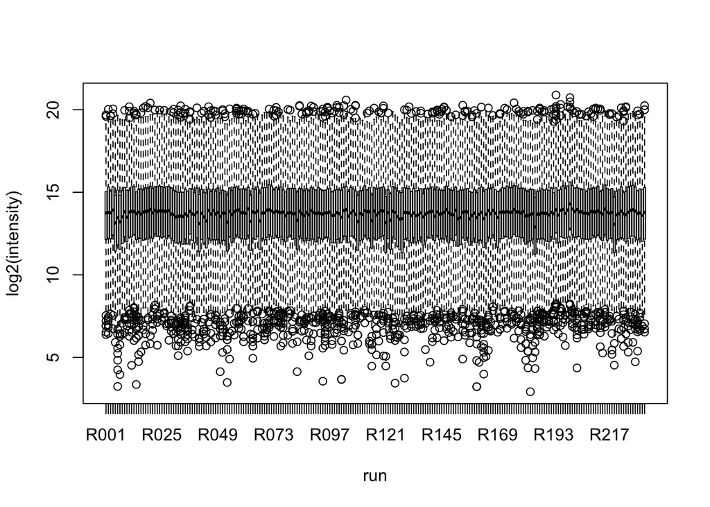

```r
plot(twin_dia3)
```

## Testing packages

It is often important to test snippets of code you include in your packages. A unit test suite is typically the best way to do this. Unit tests allow testing small, controlled portions of code with known return values.

Having a suite of unit tests can take some time investment at the beginning of development, but often makes things easier in the future.

There are multiple R packages that ease writing of unit tests, including **RUnit** and **testthat**.

For example, say we have a function `foo` that we want to test.

```r
foo <- function(x, y) x + y
```

Then with **RUnit**:

```r
library(RUnit)
checkEquals(foo(1, 1), 2)
```

```
## [1] TRUE
```

And with **testthat**:

```r
library(testthat)
expect_equal(foo(1, 1), 2)
```

Our example **ProtExp** package includes a small example unit test suite using **testthat**.

Idealy, unit tests should cover as much code in a package as is reasonably possible.

## Package vignettes

Package vignettes go in the `/vignettes` subdirectory, and can be written in Sweave (a LaTeX-based format) or in Markdown. These are created and installed automatically with a package.

Our **ProtExp** example package includes a Markdown vignette, which can be viewed using:

```r
vignette("ProtExp-demo")
```